# finalxm

## Name: Aashi Aggarwal

## Id: 8920299

Part A: Model Training and Evaluation

Q: 1. Choose a shallow (simple) classification baseline model from the ones mentioned in class after the midterm. A shallow classifier is one that doesn’t generate a complex decision boundary. We will use this classifier in the following points. Include a comment on why you choose this particular classifier and why is it considered shallow

Ans1: To make a simple starting point for classifying things, like sorting pictures into categories, I'd use Logistic Regression. It's like a basic tool that's easy to understand. Think of it as drawing a straight line to connect the features of the pictures (like colors or shapes) to figure out which category they belong to. It's not super fancy and can't handle really complex stuff, but it's good to get a basic idea. For our pictures, it works well because they have lots of features (784 pixels!) and need to be sorted into different groups.

Q2: Train the chosen baseline model on the training set. Make sure to use 5-fold cross-validation to properly judge the performance of the model on a validation set.

```python
#Libraries

import pandas as pd
from sklearn.metrics import accuracy_score
from sklearn.model_selection import train_test_split
from sklearn.tree import DecisionTreeClassifier
from sklearn.linear_model import LogisticRegression
```

```python
# Load training and testing data
x_train = pd.read_csv('C:/Users/Andy/Desktop/ML/youseffs_lab/Fall2023/students-submissions/8920299/final_exam_part_b_dataset/tests/x_train.csv')
y_train = pd.read_csv('C:/Users/Andy/Desktop/ML/youseffs_lab/Fall2023/students-submissions/8920299/final_exam_part_b_dataset/tests/y_train.csv')
x_test = pd.read_csv('C:/Users/Andy/Desktop/ML/youseffs_lab/Fall2023/students-submissions/8920299/final_exam_part_b_dataset/tests/x_test.csv')
y_test = pd.read_csv('C:/Users/Andy/Desktop/ML/youseffs_lab/Fall2023/students-submissions/8920299/final_exam_part_b_dataset/tests/y_test.csv')



# Split the data into training and validation sets
x_train, x_val, y_train, y_val = train_test_split(x_train, y_train, test_size=0.2, random_state=42)

# Flatten the target arrays
y_train, y_val = y_train.values.ravel(), y_val.values.ravel()

# Create and train the Logistic Regression model
model = LogisticRegression(max_iter=500).fit(x_train, y_train)

# Evaluate the accuracy on the validation set
accuracy = accuracy_score(y_val, model.predict(x_val))
print(f"Validation Accuracy: {accuracy * 100:.2f}%")
```

```
Validation Accuracy: 85.72%
```

```python
from sklearn.ensemble import BaggingClassifier
from sklearn.model_selection import cross_val_score

# Define the base model for bagging
base_classifier = LogisticRegression()

# Create BaggingClassifier with the base estimator
bagging_classifier = BaggingClassifier(base_estimator=base_classifier, n_estimators=10)

# Perform 5-fold cross-validation
cv_scores_bagging = cross_val_score(bagging_classifier, x_train, y_train, cv=5)

# Calculate the average accuracy across the folds
avg_accuracy_bagging = cv_scores_bagging.mean()

# Print the average cross-validation accuracy for bagging
print("Avg CV Accuracy (Bagging): {:.2f}%".format(avg_accuracy_bagging * 100))
```

[output not shown]

[output cut: 355 more lines]

[output not shown]

```
Avg CV Accuracy (Bagging): 86.15%
```

```python
from sklearn.ensemble import AdaBoostClassifier
from sklearn.model_selection import cross_val_score

# Define the base model for boosting
base_classifier = LogisticRegression()

# Create AdaBoostClassifier with the base estimator
boosting_classifier = AdaBoostClassifier(base_estimator=base_classifier, n_estimators=10)

# Perform 5-fold cross-validation
cv_scores_boosting = cross_val_score(boosting_classifier, x_train, y_train, cv=5)

# Calculate the average accuracy across the folds
avg_accuracy_boosting = cv_scores_boosting.mean()

# Print the average cross-validation accuracy for boosting
print("Avg CV Accuracy (Boosting): {:.2f}%".format(avg_accuracy_boosting * 100))
```

[output not shown]

[output cut: 259 more lines]

[output not shown]

```
Avg CV Accuracy (Boosting): 70.07%
```

```python
from sklearn.metrics import accuracy_score
from sklearn.linear_model import LogisticRegression
from sklearn.ensemble import BaggingClassifier, AdaBoostClassifier

# Load the trained baseline model (Logistic Regression)
baseline_model = LogisticRegression()
baseline_model.fit(x_train, y_train)
baseline_predictions = baseline_model.predict(x_test)
baseline_accuracy = accuracy_score(y_test, baseline_predictions)

# Load the trained bagging model with base estimator (Logistic Regression)
bagging_model = BaggingClassifier(base_estimator=baseline_model, n_estimators=10)
bagging_model.fit(x_train, y_train)
bagging_predictions = bagging_model.predict(x_test)
bagging_accuracy = accuracy_score(y_test, bagging_predictions)

# Load the trained boosting model with base estimator (Logistic Regression)
boosting_model = AdaBoostClassifier(base_estimator=baseline_model, n_estimators=10)
boosting_model.fit(x_train, y_train)
boosting_predictions = boosting_model.predict(x_test)
boosting_accuracy = accuracy_score(y_test, boosting_predictions)

# Compare the performance
print("Baseline Model Accuracy: {:.2f}%".format(baseline_accuracy * 100))
print("Bagging Model Accuracy: {:.2f}%".format(bagging_accuracy * 100))
print("Boosting Model Accuracy: {:.2f}%".format(boosting_accuracy * 100))
```

[output not shown]

[output cut: 93 more lines]

[output not shown]

```
Baseline Model Accuracy: 85.04%
Bagging Model Accuracy: 85.11%
Boosting Model Accuracy: 69.31%
```

Part B : Guessing the Mystery Label In this part, we will try to use Dimensionality Reduction and Clustering techniques to guess what the mystery labels in the dataset are. Specifically, the deliverables for the section are as follows (can be done in any order):

1. Carry out PCA and LDA to reduce the dimensionality of the original training data points to 2. Produce a plot of the data in two dimensions for PCA and LDA, using easily distinguishable colours and markers to indicate the labels of each datapoint. Include a comment on any interesting patterns you see in the two plots

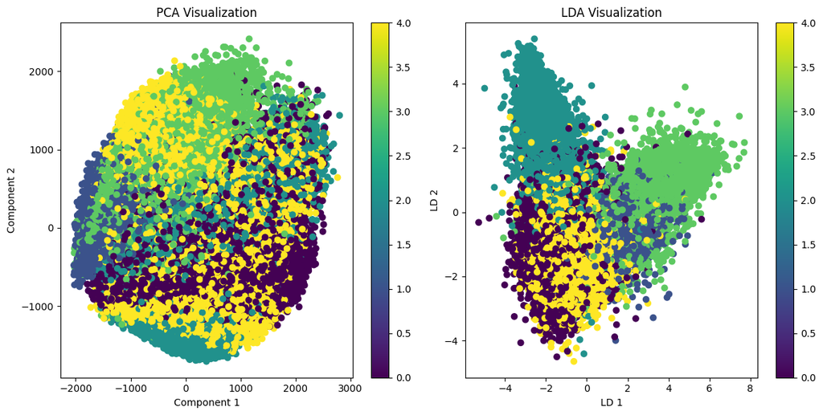

```python
import matplotlib.pyplot as plt
from sklearn.decomposition import PCA
from sklearn.discriminant_analysis import LinearDiscriminantAnalysis as LDA

# Apply PCA
pca_model = PCA(n_components=2)
x_train_pca = pca_model.fit_transform(x_train)

# Apply LDA
lda_model = LDA(n_components=2)
x_train_lda = lda_model.fit_transform(x_train, y_train)

# Plot PCA and LDA
plt.figure(figsize=(12, 6))

# Visualize PCA
plt.subplot(1, 2, 1)
plt.scatter(x_train_pca[:, 0], x_train_pca[:, 1], c=y_train, cmap='viridis')
plt.title('PCA Visualization')
plt.xlabel('Component 1')
plt.ylabel('Component 2')
plt.colorbar()

# Visualize LDA
plt.subplot(1, 2, 2)
plt.scatter(x_train_lda[:, 0], x_train_lda[:, 1], c=y_train, cmap='viridis')
plt.title('LDA Visualization')
plt.xlabel('LD 1')
plt.ylabel('LD 2')
plt.colorbar()

plt.tight_layout()
plt.show()
```

PCA Plot:

The PCA plot shows a smooth color transition, indicating a gradual change in the data. Colors overlap in the middle, suggesting some similarity between represented items. LDA Plot:

PCA's spread indicates wide feature variation. LDA's tighter clusters suggest better class separability with label info. Overlap in both plots implies some common features between classes, typical for clothing items.

2. Carry out K-Means on the original data points with 5 clusters and visualize the results by using the resulting clusters as alternate colour mappings for the PCA plot above.

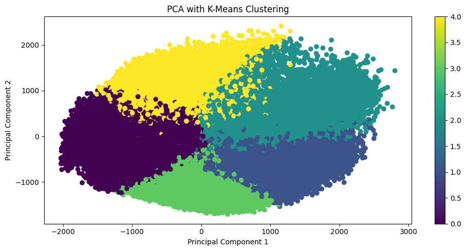

```python
import matplotlib.pyplot as plt
from sklearn.decomposition import PCA
from sklearn.cluster import KMeans

# We will perform PCA
pca = PCA(n_components=2)
x_train_pca = pca.fit_transform(x_train)

# We will perform K-Means clustering
kmeans = KMeans(n_clusters=5)
kmeans.fit(x_train)

# We will get the cluster labels
cluster_labels = kmeans.labels_

# We will plot PCA with cluster labels as colors
plt.figure(figsize=(10, 5))
plt.scatter(x_train_pca[:, 0], x_train_pca[:, 1], c=cluster_labels, cmap='viridis')
plt.title('PCA with K-Means Clustering')
plt.xlabel('Principal Component 1')
plt.ylabel('Principal Component 2')
plt.colorbar()

plt.tight_layout()
plt.show()
```

3. Based on the results seen in the plots, can you guess what are the labels for the given dataset (what each label number represents in terms of the category of clothes)? It might also help to list out a random selection of data entries (the original images) for each cluster and their label value to help understand the patterns each cluster might represent.

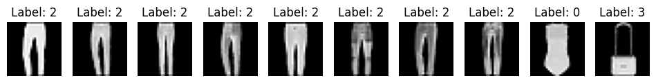

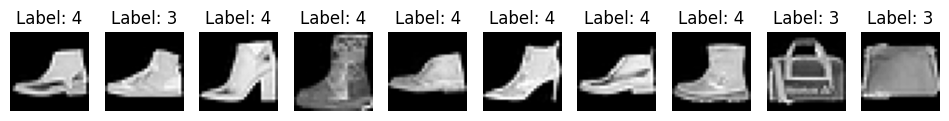

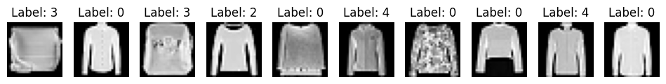

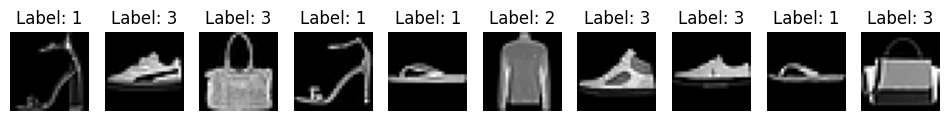

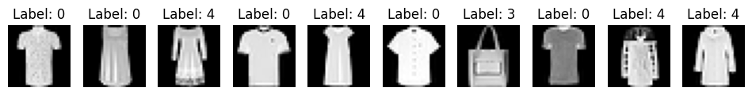

```
Analysis of Clusters:
Cluster 0: Possible Label - (2,)
Cluster 1: Possible Label - (4,)
Cluster 2: Possible Label - (2,)
Cluster 3: Possible Label - (3,)
Cluster 4: Possible Label - (0,)
```

```python
# Load datasets
import numpy as np
x_data = pd.read_csv('C:/Users/Andy/Desktop/ML/youseffs_lab/Fall2023/students-submissions/8920299/final_exam_part_b_dataset/tests/x_train.csv').astype('float32')
y_labels = pd.read_csv('C:/Users/Andy/Desktop/ML/youseffs_lab/Fall2023/students-submissions/8920299/final_exam_part_b_dataset/tests/y_train.csv').astype('int32')
#x_train = pd.read_csv('C:/Users/Andy/Desktop/ML/youseffs_lab/Fall2023/students-submissions/8920299/final_exam_part_b_dataset/tests/x_train.csv')
#y_train = pd.read_csv('C:/Users/Andy/Desktop/ML/youseffs_lab/Fall2023/students-submissions/8920299/final_exam_part_b_dataset/tests/y_train.csv')

# Apply PCA for 2D visualization
pca = PCA(n_components=2)
x_data_pca = pca.fit_transform(x_data)

# K-Means clustering with 5 clusters
kmeans = KMeans(n_clusters=5, random_state=42)
kmeansClusters = kmeans.fit_predict(x_data)

# Function to plot images for a specific cluster
def plot_images_for_cluster(cluster_index, num_images=10):
    cluster_indices = np.where(kmeansClusters == cluster_index)[0]

    if not cluster_indices.any():
        print(f"No data points in Cluster {cluster_index}. Skipping...")
        return

    random_indices = np.random.choice(cluster_indices, num_images, replace=False)

    # Plot each image in the subset
    fig, axes = plt.subplots(1, num_images, figsize=(12, 2))
    for ax, idx in zip(axes, random_indices):
        # Reshape the 784 features back into a 28x28 image
        image = x_data.iloc[idx].values.reshape(28, 28)
        ax.imshow(image, cmap='gray')
        ax.axis('off')
        ax.set_title(f'Label: {y_labels.iloc[idx].item()}')
    plt.show()

# Visualize random images from each cluster
for cluster_num in range(5):
    plot_images_for_cluster(cluster_index=cluster_num)

# Analyze clusters and suggest possible labels
print("\nAnalysis of Clusters:")
for cluster_num in range(5):
    cluster_indices = np.where(kmeansClusters == cluster_num)[0]
    if cluster_indices.any():
        cluster_labels = y_labels.iloc[cluster_indices].value_counts().idxmax()
        print(f"Cluster {cluster_num}: Possible Label - {cluster_labels}")
    else:
        print(f"Cluster {cluster_num}: No data points")
```

Cluster Interpretations: